# 06.4: CouchDB

[figure not shown]

# 2 / 4: Couchbase

[figure not shown]

# 3 / 4: Architecture

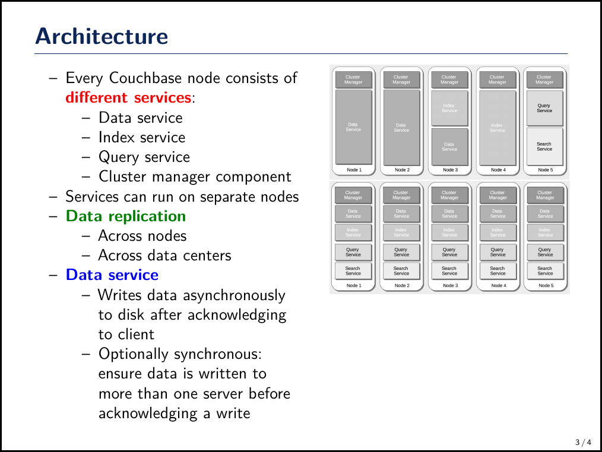

- **Every Couchbase node consists of different services:**
  - **Data service:** Manages the storage and retrieval of data. It handles the core database operations.
  - **Index service:** Creates and manages indexes to speed up query operations.
  - **Query service:** Processes queries and interacts with the data and index services to retrieve results.
  - **Cluster manager component:** Oversees the coordination and management of the cluster, ensuring all nodes work together efficiently.
- **Services can run on separate nodes:**
  - This allows for flexibility and scalability. By distributing services across nodes, the system can handle more load and provide redundancy.
- **Data replication:**
  - **Across nodes:** Ensures data availability and fault tolerance within the cluster.
  - **Across data centers:** Provides disaster recovery and data locality for global applications.
- **Data service:**
  - **Writes data asynchronously to disk after acknowledging to client:** This improves performance by allowing the system to continue processing without waiting for disk operations.
  - **Optionally synchronous:** Ensures data is written to multiple servers before acknowledging a write, enhancing data durability and consistency.

# 4 / 4: Queries

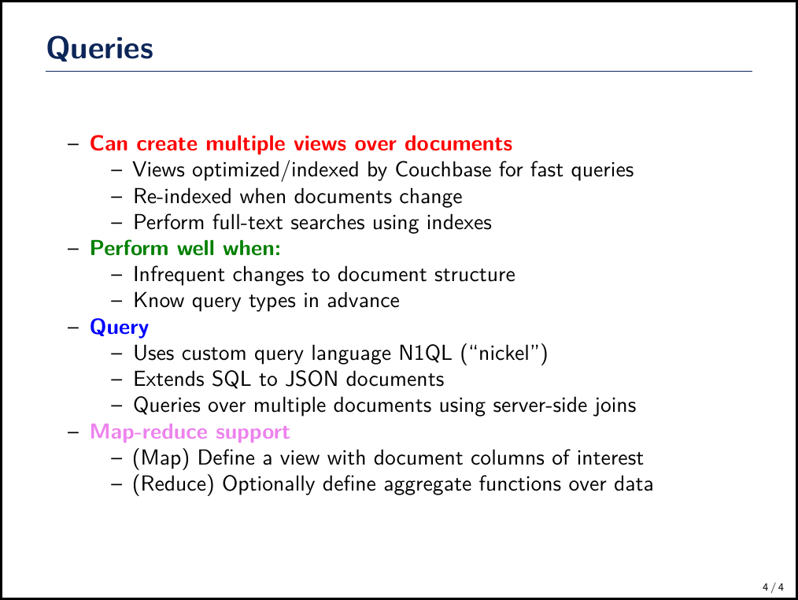

- **Queries**
  - *Can create multiple views over documents*: This means you can have different perspectives or ways to look at your data. Couchbase allows you to set up these views so that they are specifically designed to make searching through your data fast and efficient. When you update your documents, these views are automatically updated, or re-indexed, to reflect the changes. This ensures that your searches are always based on the most current data. Additionally, you can perform full-text searches, which means you can search for specific words or phrases within your documents using these indexes.
- **Perform well when:**
  - *Infrequent changes to document structure*: Couchbase is particularly effective when the structure of your documents doesn’t change often. This stability allows the system to maintain efficient indexes and views without needing constant updates.
  - *Know query types in advance*: If you can anticipate the types of queries you’ll need to run, you can optimize your views and indexes accordingly. This foresight helps in setting up the database to handle those queries quickly and efficiently.
- **Query**
  - *Uses custom query language N1QL (“nickel”)*: N1QL is a query language developed by Couchbase that extends the familiar SQL language to work with JSON documents. This means if you’re familiar with SQL, you can easily adapt to using N1QL for querying Couchbase databases. It allows you to perform complex queries, including joining data from multiple documents directly on the server, which can simplify data retrieval and processing.
- **Map-reduce support**
  - *(Map) Define a view with document columns of interest*: The map function lets you specify which parts of your documents you want to focus on. This is useful for creating views that only include the data you need, making queries faster and more efficient.
  - *(Reduce) Optionally define aggregate functions over data*: The reduce function allows you to perform calculations or aggregations on your data, such as summing values or counting occurrences. This can be particularly useful for generating reports or summaries directly from your database without needing additional processing.